# Propensity Score Matching With Average Treatment Effect (TWANG package)

Anahita Kumar

2023-03-16

overview: PSM using average treatment effect (TWANG package), followed by causal inference using the matched dataset as a robustness check of results from an unmatched dataset.

## 1 Sample Code and Statistical Output

This document provides the code and output for a part of the analysis of an experimental intervention conducted in Mumbai, India. The project was a pre-registered trial, and the manuscript detailing the findings is currently under peer review for academic publication. The author, as the principal investigator of this study, conceptualized the program design, oversaw its implementation, and conducted all statistical analyses.

```r
parents_comparison <- parents_comparison %>%
  mutate_at(vars(starts_with("M")), ~ na_if(., 88)) %>%
  mutate_at(vars(starts_with("G"), -ends_with("5")), ~ na_if(., 88)) %>%
  select(everything())

parents_endline_data <- read.csv("parents_endline_data.csv")
parents_endline_data$ID <- parents_endline_data$A01

parents_endline_data <- parents_endline_data %>%
  select(starts_with("V"), "ID") %>%
  mutate_at(vars(starts_with("V"), -ends_with("8")), ~ na_if(., 88)) %>%
  mutate_at(vars(starts_with("V"), -ends_with("8")), ~ na_if(., 99))

parents_comparison <- parents_comparison %>%
  inner_join(parents_endline_data, by = "ID")
```

Procedure based on https://cran.r-project.org/web/packages/twang/vignettes/twang.pdf, following the Typical workflow with twang (section 2.4).

1. Determine the estimand of interest, either ATE or ATT. We choose to estimate the ATE (average treatment effect).
2. Determine the observed confounding factors to be balanced. Already determined, C2 = parent age C4 = child age C5 = marital status N01 = parent school aspiration N02 = parent school expectation discipline = harsh discipline practices food_before_covid = food insecurity pre-covid food_during_covid = food insecurity during covid support_z = parent support, standardized A04 = school stratification A08 = child gender
3. Fit the propensity score model using the ps() function.
- Evaluate the convergence of the algorithm.
- Assess the balance of the confounding factors before and after applying the propensity score weights.
- If needed, rerun the algorithm adjusting the gradient boosting parameters to achieve convergence or improve balance.

The saved object psm_test1 is of class ps and contains the propensity score model fit information. We will work with this object to assess model convergence, to assess the balance of pretreatment characteristics, and to extract the propensity score weights needed for subsequent analysis. By default, the ps() function uses the gbm package for gradient boosting. A user can request use of xgboost by specifying the option version=“xgboost”. The use of xgboost is not be discussed further in the tutorial we used. See the documentation for additional details.

## 2 Running Diagnostic Tests

As a default, the plot() function applied to a ps object gives the balance measures as a function of the number of iterations in the gradient boosting algorithm, with higher iterations corresponding to more complicated fitted models. This figure also gives information on how compatible two or more stopping rules are: if the minima for multiple stopping rules under consideration are near one another, the results should not be sensitive to which stopping rule one uses for the final analysis.

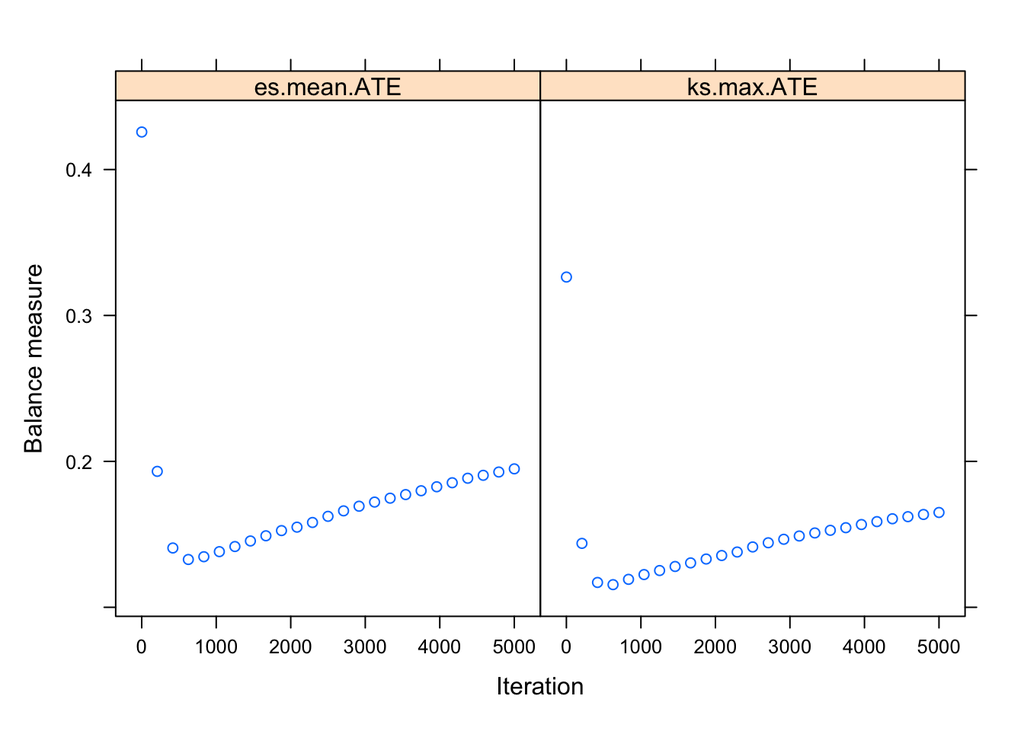

## 3 Assessing balance using balance tables

```r
psm_balance <- bal.table(psm_test1)
psm_balance
```

```
## $unw
##                   tx.mn tx.sd  ct.mn ct.sd std.eff.sz   stat  pval    ks
## C2               38.783 7.985 36.893 7.759      0.239  2.602 0.010 0.161
## C4                4.416 2.230  5.648 2.295     -0.525 -5.906 0.000 0.268
## C5                0.801 0.400  0.914 0.281     -0.325 -3.522 0.000 0.113
## N01               3.465 1.193  3.139 1.304      0.258  2.827 0.005 0.179
## N02               3.863 1.064  4.135 1.116     -0.248 -2.712 0.007 0.205
## discipline        2.031 1.721  2.914 1.357     -0.551 -6.150 0.000 0.272
## foodprecovid      0.438 0.497  0.602 0.490     -0.329 -3.609 0.000 0.164
## foodcovid         0.792 1.130  1.230 1.150     -0.377 -4.163 0.000 0.241
## supportz         -0.392 0.990  0.000 1.000     -0.387 -4.269 0.000 0.208
## school:HMES       0.650 0.477  0.980 0.142     -0.859 43.204 0.000 0.329
## school:Holy Star  0.173 0.378  0.008 0.090      0.583     NA    NA 0.164
## school:SVN        0.177 0.382  0.012 0.110      0.571     NA    NA 0.165
## A08               1.562 0.497  1.402 0.500      0.318  3.488 0.001 0.156
##                  ks.pval
## C2                 0.005
## C4                 0.000
## C5                 0.100
## N01                0.001
## N02                0.000
## discipline         0.000
## foodprecovid       0.004
## foodcovid          0.000
## supportz           0.000
## school:HMES        0.000
## school:Holy Star      NA
## school:SVN            NA
## A08                0.007
##
## $es.mean.ATE
##                   tx.mn tx.sd  ct.mn ct.sd std.eff.sz   stat  pval    ks
## C2               37.857 7.904 37.513 8.331      0.043  0.390 0.697 0.063
## C4                4.985 2.348  5.318 2.296     -0.142 -1.383 0.167 0.074
## C5                0.853 0.355  0.896 0.306     -0.124 -1.176 0.240 0.043
## N01               3.309 1.252  3.196 1.272      0.089  0.887 0.376 0.069
## N02               3.975 1.089  4.001 1.167     -0.024 -0.218 0.828 0.064
## discipline        2.466 1.650  2.759 1.431     -0.183 -1.794 0.073 0.105
## foodprecovid      0.528 0.500  0.568 0.496     -0.081 -0.781 0.435 0.040
## foodcovid         1.011 1.189  1.121 1.145     -0.095 -0.925 0.355 0.086
```

[output cut: 34 more lines]

```
## A08               1.518 0.501  1.457 0.506      0.121  1.173 0.241 0.058
##                  ks.pval
## C2                 0.859
## C4                 0.654
## C5                 0.992
## N01                0.749
## N02                0.800
## discipline         0.228
## foodprecovid       0.998
## foodcovid          0.441
## supportz           0.791
## school:HMES        0.125
## school:Holy Star      NA
## school:SVN            NA
## A08                0.910
```

```r
summary(psm_test1)
```

```
##             n.treat n.ctrl ess.treat ess.ctrl    max.es   mean.es    max.ks
## unw             226    244  226.0000 244.0000 0.8589091 0.4283809 0.3290657
## es.mean.ATE     226    244  185.6259 190.4001 0.3029747 0.1320597 0.1160758
## ks.max.ATE      226    244  187.1681 191.2289 0.2986265 0.1328045 0.1144100
##             max.ks.p    mean.ks iter
## unw               NA 0.20205281   NA
## es.mean.ATE       NA 0.06874297  669
## ks.max.ATE        NA 0.06981115  572
```

## 4 Graphical assessments of balance

Specifying plots = 2 or plots = “boxplot” produces boxplots illustrating the spread of the estimated propensity scores in the treatment and comparison groups. Whereas propensity score stratification requires considerable overlap in these spreads, excellent covariate balance can often be achieved with weights, even when the propensity scores estimated for the treatment and control groups show little overlap.

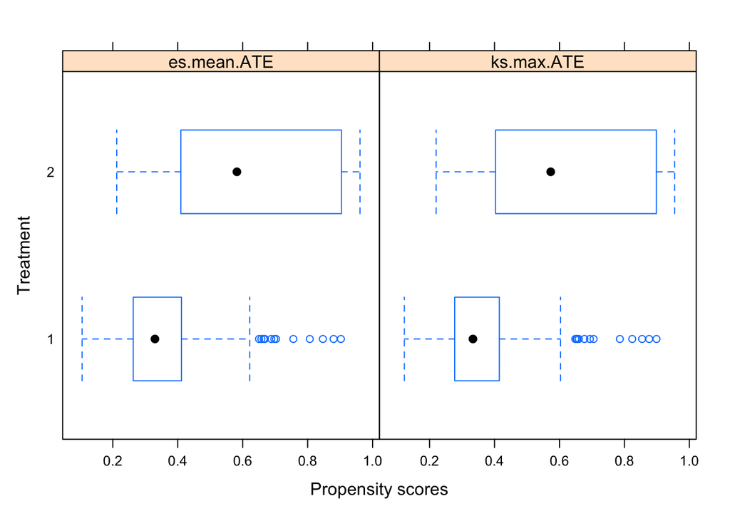

```r
plot(psm_test1, plots = 2)
```

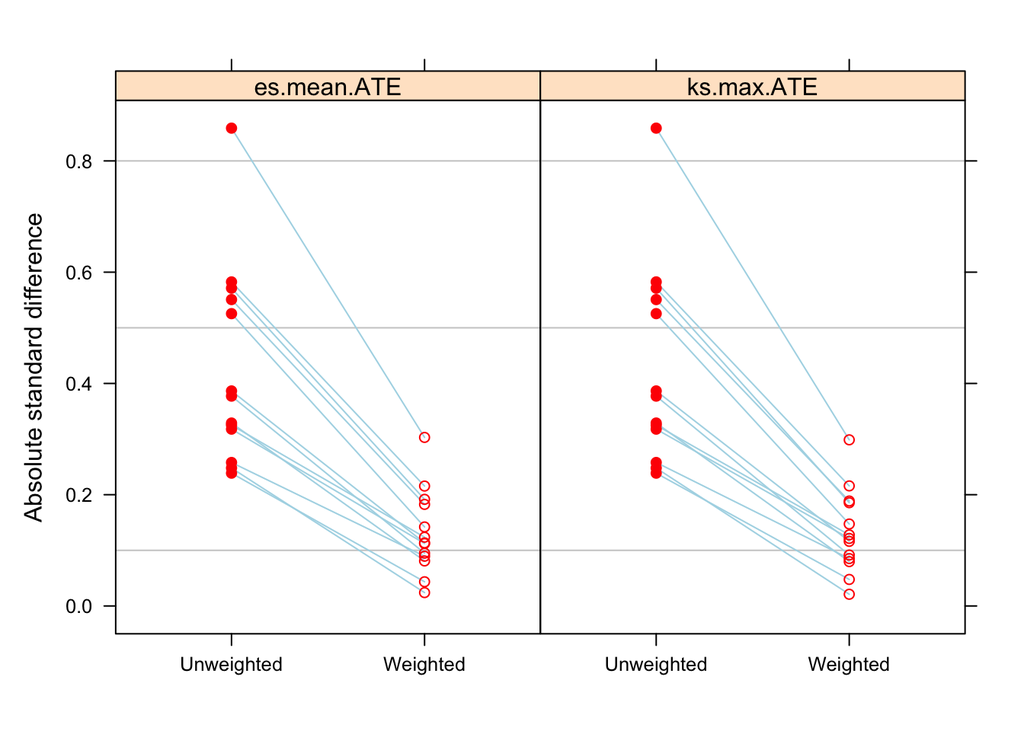

```r
plot(psm_test1, plots = 3)
```

When many of the p-values testing individual covariates for balance are very small, the groups are clearly imbalanced and inconsistent with what we would expect had the groups been formed by random assignment. After weighting we would expect the p-values to be larger if balance had been achieved. We use a QQ plot comparing the quantiles of the observed p-values to the quantiles of the uniform distribution (45 degree line) to conduct this check of balance. Ideally, the p-values from independent tests in which the null hypothesis is true will have a uniform distribution. Although the ideal is unlikely to hold even if we had random assignment (Bland, 2013), severe deviation of the p-values below the diagonal suggests lack of balance and p-values running at or above the diagonal suggests balance might have been achieved. The p-value plot (plots=4 or plots=“t”) allows users to visually to inspect the p-values of the t-tests for group differences in the covariate means. Our results are not great, but one can see they approach the diagonal distrbution.

Before weighting (closed circles), the groups have statistically significant differences on many variables (i.e., p-values are near zero). After weighting (open circles) the p-values are generally slightly below the 45-degree line, which represents the cumulative distribution of a uniform variable on [0,1]. This indicates that the p-values are slightly lower than would be expected in a randomized study.

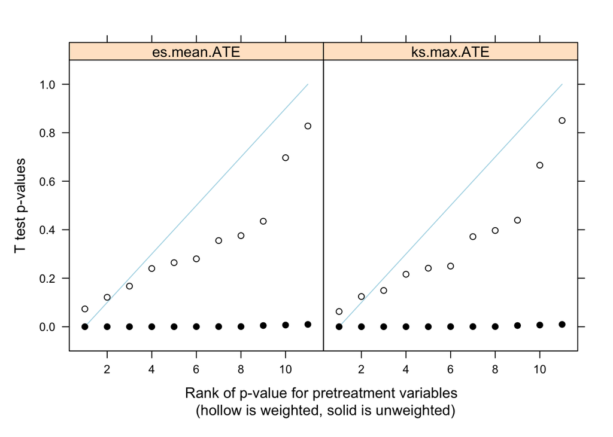

```r
plot(psm_test1, plots = 4)
```

One can inspect similar plots for the KS statistic, which in this case is better:

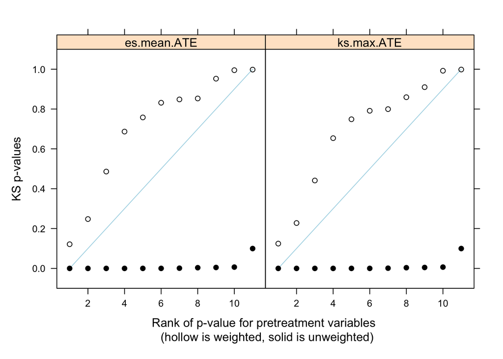

```r
plot(psm_test1, plots = 5)
```

The gbm package has various tools for exploring the relationship between the covariates and the treatment assignment indicator if these are of interest. These tools can be used with the ps object to extract useful information. In particular, the summary() function applied to the underling gbm object computes the relative influence of each variable for estimating the probability of treatment assignment. The relaive influence of each variable changes as more iteration are added to the gradient boosted model. In this example, we choose the number of iterations to be the optimal number for minimizing the largest of the KS statistics. This value can be found in the ps.lalonde.gbm$desc$ks.max.ATT$n.trees. Figure 1 shows the barchart of the relative influence and is produced when plot=TRUE in the call to summary().

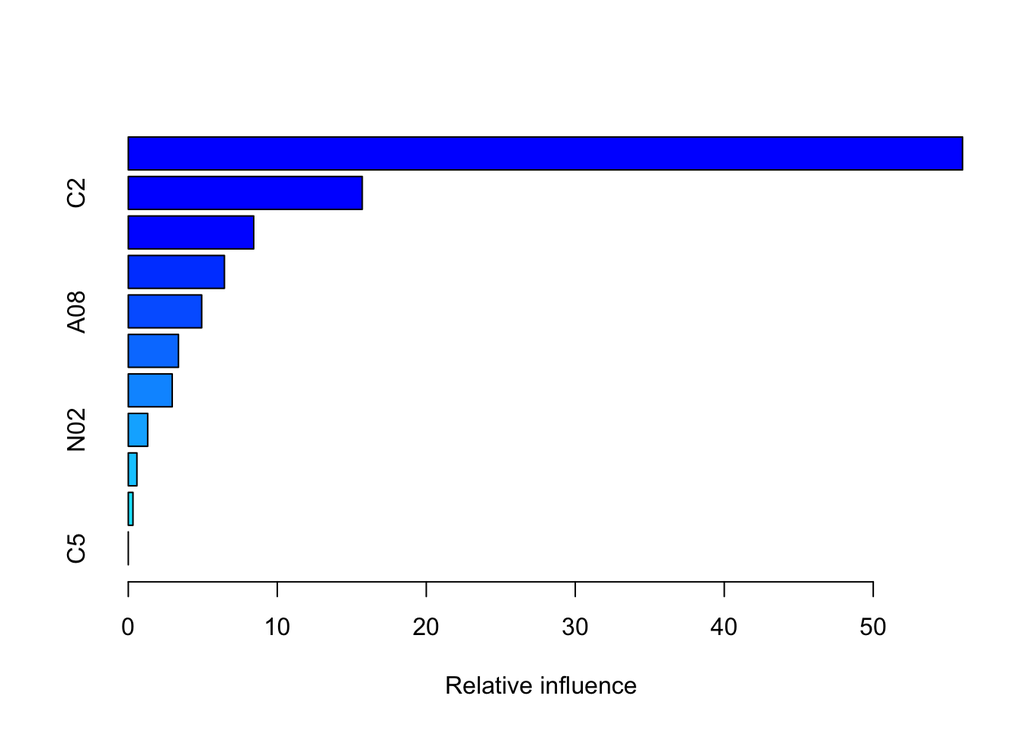

```
##                       var    rel.inf
## school             school 55.9945748
## C2                     C2 15.7020377
## foodcovid       foodcovid  8.4174355
## C4                     C4  6.4509515
## A08                   A08  4.9256784
## supportz         supportz  3.3665633
## discipline     discipline  2.9479416
## N02                   N02  1.3020947
## foodprecovid foodprecovid  0.5783432
## N01                   N01  0.3143794
## C5                     C5  0.0000000
```

## 5 Extract the propensity score weights

Extract the propensity score weights and fit a weighted model to estimate the treatment effect.

```
##
## Call:
## svyglm(formula = socem_total_el_z ~ treated + socem_total_bl__z,
##     design = design.ps, rescale = T)
##
## Survey design:
## svydesign(ids = ~1, weights = ~w, data = parents_comparison)
##
## Coefficients:
##                   Estimate Std. Error t value Pr(>|t|)
## (Intercept)        0.01217    0.06755   0.180   0.8571
## treated            0.27764    0.10978   2.529   0.0118 *
## socem_total_bl__z  0.15384    0.06283   2.448   0.0147 *
## ---
## Signif. codes:  0 '***' 0.001 '**' 0.01 '*' 0.05 '.' 0.1 ' ' 1
##
## (Dispersion parameter for gaussian family taken to be 1.386611)
##
## Number of Fisher Scoring iterations: 2
```

```
##
## Call:
## svyglm(formula = socem_total_el_z ~ treated + socem_total_bl__z +
##     school, design = design.ps, rescale = T)
##
## Survey design:
## svydesign(ids = ~1, weights = ~w, data = parents_comparison)
##
## Coefficients:
##                   Estimate Std. Error t value Pr(>|t|)
## (Intercept)        0.03136    0.06937   0.452  0.65137
## treated            0.31124    0.11658   2.670  0.00786 **
## socem_total_bl__z  0.14669    0.06715   2.184  0.02943 *
## schoolHoly Star   -0.58613    0.29882  -1.961  0.05042 .
## schoolSVN          0.02570    0.25450   0.101  0.91961
## ---
## Signif. codes:  0 '***' 0.001 '**' 0.01 '*' 0.05 '.' 0.1 ' ' 1
##
## (Dispersion parameter for gaussian family taken to be 1.365118)
##
## Number of Fisher Scoring iterations: 2
```

## 6 Run heterogeneity analyses

Run heterogeneity analyses using the propensity score weights and fit a weighted model to estimate the treatment effect.

```r
library(survey)
library(ggplot2)

predictedvars <- parents_comparison %>% select("X.1", "ID", "treated", "PED2",
                                               starts_with("socem"),
                                               ends_with("mat_ed"),
                                               starts_with("covid"),
                                               starts_with("educ_eng"))

#Maternal education
```

## 7 Heterogeneity with PSM model

```r
glmSE_continuous_mat_ed <- svyglm(socem_total_el_z ~ socem_total_bl__z + school + treated*PED2 , design = design.ps, rescale = T)
summary(glmSE_continuous_mat_ed) #maternal education doesn't make a difference
```

```
##
## Call:
## svyglm(formula = socem_total_el_z ~ socem_total_bl__z + school +
##     treated * PED2, design = design.ps, rescale = T)
##
## Survey design:
## svydesign(ids = ~1, weights = ~w, data = parents_comparison)
##
## Coefficients:
##                   Estimate Std. Error t value Pr(>|t|)
## (Intercept)       -0.09610    0.17417  -0.552   0.5814
## socem_total_bl__z  0.13459    0.06837   1.968   0.0496 *
## schoolHoly Star   -0.55935    0.30331  -1.844   0.0658 .
## schoolSVN          0.03478    0.26111   0.133   0.8941
## treated            0.27153    0.29222   0.929   0.3533
## PED2               0.04437    0.05109   0.868   0.3856
## treated:PED2       0.01627    0.09030   0.180   0.8571
## ---
## Signif. codes:  0 '***' 0.001 '**' 0.01 '*' 0.05 '.' 0.1 ' ' 1
##
## (Dispersion parameter for gaussian family taken to be 1.361003)
##
## Number of Fisher Scoring iterations: 2
```

```r
glmSE_prim_mat_ed <- svyglm(socem_total_el_z ~ treated*prim_mat_ed + socem_total_bl__z + school, design = design.ps, rescale = T)
summary(glmSE_prim_mat_ed)
```

```
##
## Call:
## svyglm(formula = socem_total_el_z ~ treated * prim_mat_ed + socem_total_bl__z +
##     school, design = design.ps, rescale = T)
##
## Survey design:
## svydesign(ids = ~1, weights = ~w, data = parents_comparison)
##
## Coefficients:
##                       Estimate Std. Error t value Pr(>|t|)
## (Intercept)           0.026262   0.171404   0.153   0.8783
## treated               0.278819   0.291349   0.957   0.3391
## prim_mat_ed1          0.005345   0.188343   0.028   0.9774
## socem_total_bl__z     0.144989   0.065637   2.209   0.0277 *
## schoolHoly Star      -0.584290   0.299577  -1.950   0.0517 .
## schoolSVN             0.032149   0.262655   0.122   0.9026
## treated:prim_mat_ed1  0.038868   0.312043   0.125   0.9009
## ---
## Signif. codes:  0 '***' 0.001 '**' 0.01 '*' 0.05 '.' 0.1 ' ' 1
##
## (Dispersion parameter for gaussian family taken to be 1.364976)
##
## Number of Fisher Scoring iterations: 2
```

```r
glmSE_sec_mat_ed <- svyglm(socem_total_el_z ~ treated*sec_mat_ed + socem_total_bl__z + school, design = design.ps, rescale = T)
summary(glmSE_sec_mat_ed)
```

```
##
## Call:
## svyglm(formula = socem_total_el_z ~ treated * sec_mat_ed + socem_total_bl__z +
##     school, design = design.ps, rescale = T)
##
## Survey design:
## svydesign(ids = ~1, weights = ~w, data = parents_comparison)
##
## Coefficients:
##                     Estimate Std. Error t value Pr(>|t|)
## (Intercept)          0.01916    0.11464   0.167   0.8674
## treated              0.28010    0.17563   1.595   0.1114
## sec_mat_ed1          0.02054    0.14213   0.144   0.8852
## socem_total_bl__z    0.13909    0.07060   1.970   0.0494 *
## schoolHoly Star     -0.57834    0.29848  -1.938   0.0533 .
## schoolSVN            0.03154    0.25636   0.123   0.9021
## treated:sec_mat_ed1  0.06612    0.22973   0.288   0.7736
## ---
## Signif. codes:  0 '***' 0.001 '**' 0.01 '*' 0.05 '.' 0.1 ' ' 1
##
## (Dispersion parameter for gaussian family taken to be 1.364176)
##
## Number of Fisher Scoring iterations: 2
```

```r
glmSE_none_mat_ed <- svyglm(socem_total_el_z ~ treated*none_mat_ed + socem_total_bl__z + school, design = design.ps, rescale = T)
summary(glmSE_none_mat_ed)
```

```
##
## Call:
## svyglm(formula = socem_total_el_z ~ treated * none_mat_ed + socem_total_bl__z +
##     school, design = design.ps, rescale = T)
##
## Survey design:
## svydesign(ids = ~1, weights = ~w, data = parents_comparison)
##
## Coefficients:
##                       Estimate Std. Error t value Pr(>|t|)
## (Intercept)           0.031607   0.076140   0.415   0.6782
## treated               0.317686   0.124577   2.550   0.0111 *
## none_mat_ed1         -0.005345   0.188343  -0.028   0.9774
## socem_total_bl__z     0.144989   0.065637   2.209   0.0277 *
## schoolHoly Star      -0.584290   0.299577  -1.950   0.0517 .
## schoolSVN             0.032149   0.262655   0.122   0.9026
## treated:none_mat_ed1 -0.038868   0.312043  -0.125   0.9009
## ---
## Signif. codes:  0 '***' 0.001 '**' 0.01 '*' 0.05 '.' 0.1 ' ' 1
##
## (Dispersion parameter for gaussian family taken to be 1.364976)
##
## Number of Fisher Scoring iterations: 2
```

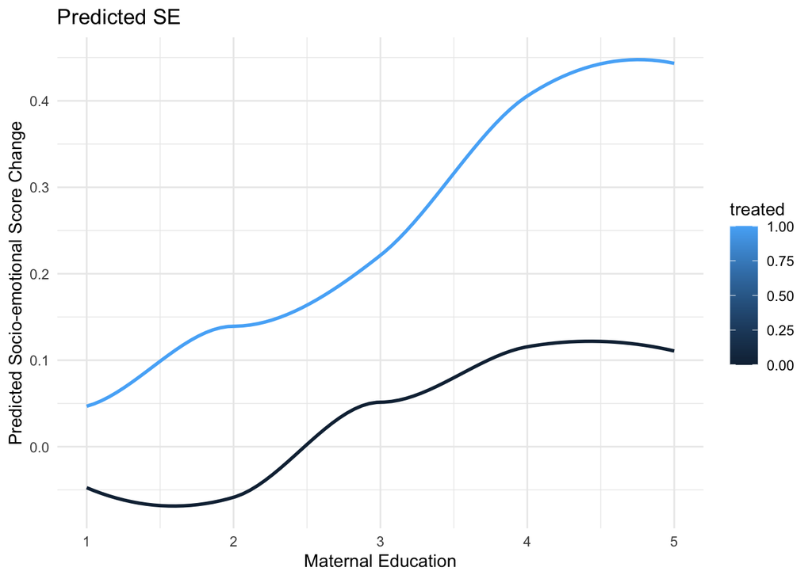

```r
predictedvars$predSE_contME <- predict.glm(glmSE_continuous_mat_ed)
predictedvars$predSE_primME <- predict.glm(glmSE_prim_mat_ed)
predictedvars$predSE_secME <- predict.glm(glmSE_sec_mat_ed)
predictedvars$predSE_noneME <- predict.glm(glmSE_none_mat_ed)


ggplot(predictedvars, aes(x= PED2, y= predSE_contME, group= treated, color= treated)) +
  #geom_point() +             # Scatter plot of the actual data points
  #geom_line() +              # Overlay two lines based on group_var
  geom_smooth(se = F, method = "loess") +
  labs(x = "Maternal Education", y = "Predicted Socio-emotional Score Change") +   # Axis labels
  ggtitle("Predicted SE") +  # Plot title
  theme_minimal()
```

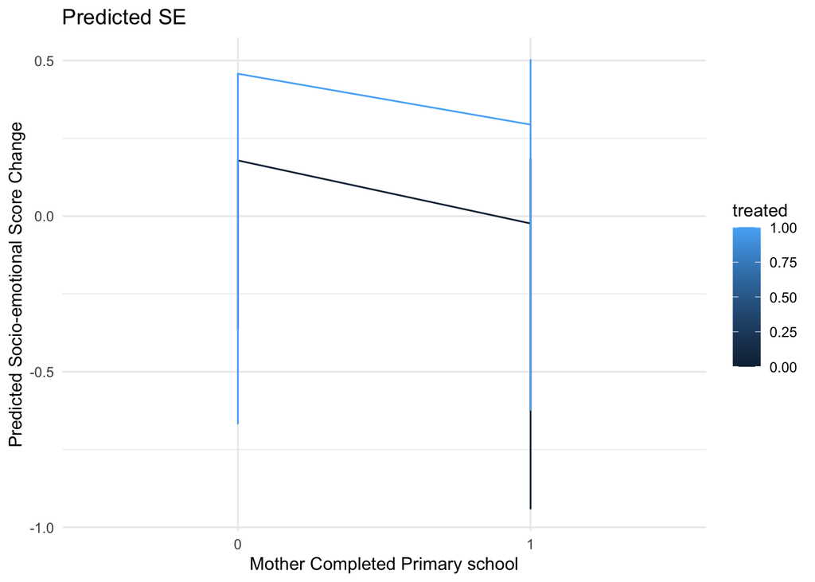

```r
ggplot(predictedvars, aes(x= prim_mat_ed, y= predSE_primME, group= treated, color= treated)) +
  #geom_point() +             # Scatter plot of the actual data points
  geom_line() +              # Overlay two lines based on group_var
  #geom_smooth(se = F, method = "loess") +
  labs(x = "Mother Completed Primary school", y = "Predicted Socio-emotional Score Change") +   # Axis labels
  ggtitle("Predicted SE") +  # Plot title
  theme_minimal()
```

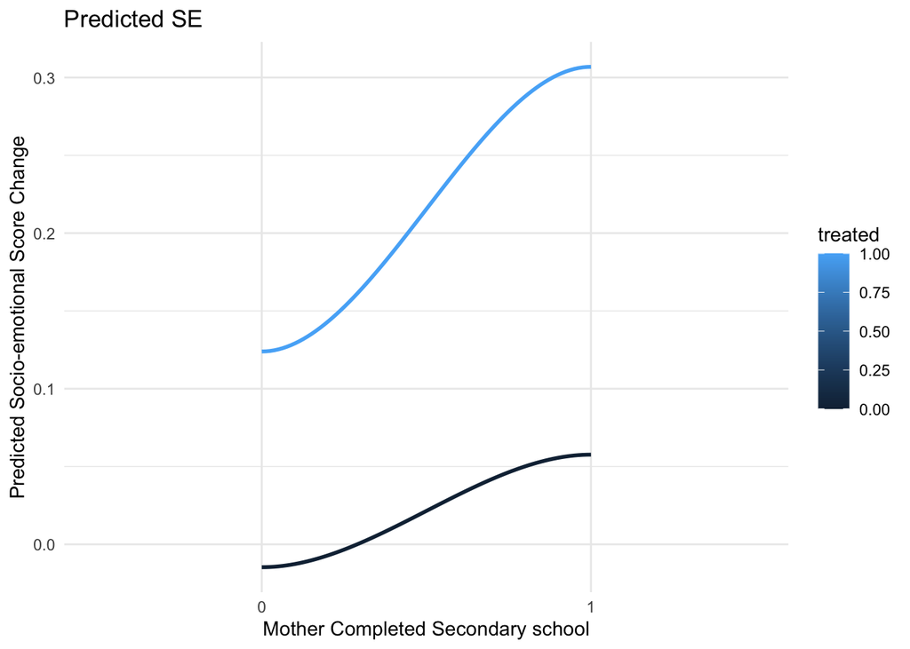

```r
ggplot(predictedvars, aes(x= sec_mat_ed, y= predSE_secME, group= treated, color= treated)) +
  #geom_point() +             # Scatter plot of the actual data points
  #geom_line() +              # Overlay two lines based on group_var
  geom_smooth(se = F, method = "loess") +
  labs(x = "Mother Completed Secondary school", y = "Predicted Socio-emotional Score Change") +   # Axis labels
  ggtitle("Predicted SE") +  # Plot title
  theme_minimal()
```

```r
#ggplot(predictedvars, aes(x= none_mat_ed, y= predSE_noneME, group= treated, color= treated)) +
  #geom_point() +             # Scatter plot of the actual data points
  #geom_line() +              # Overlay two lines based on group_var
 # geom_smooth(se = F, method = "loess") +
  #labs(x = "Mother has no schooling", y = "Predicted Socio-emotional Score Change") +   # Axis labels
  #ggtitle("Predicted SE") +  # Plot title
  #theme_minimal()

#Maternal education, different measures, predicting endline educational engagement
glmEE_continuous_mat_ed <- svyglm(educ_engagement_endline ~ treated*PED2 + educ_engagement + school, design = design.ps, rescale = T)
summary(glmEE_continuous_mat_ed) #maternal education doesn't make a difference
```

```
##
## Call:
## svyglm(formula = educ_engagement_endline ~ treated * PED2 + educ_engagement +
##     school, design = design.ps, rescale = T)
##
## Survey design:
## svydesign(ids = ~1, weights = ~w, data = parents_comparison)
##
## Coefficients:
##                 Estimate Std. Error t value Pr(>|t|)
## (Intercept)      2.81790    0.44138   6.384 4.19e-10 ***
## treated          0.02075    0.54451   0.038  0.96962
## PED2             0.10408    0.14049   0.741  0.45917
## educ_engagement  0.09312    0.06161   1.511  0.13135
## schoolHoly Star -0.17989    0.31219  -0.576  0.56476
## schoolSVN        1.74480    0.56040   3.114  0.00196 **
## treated:PED2     0.07885    0.18750   0.421  0.67431
## ---
## Signif. codes:  0 '***' 0.001 '**' 0.01 '*' 0.05 '.' 0.1 ' ' 1
##
## (Dispersion parameter for gaussian family taken to be 4.551615)
##
## Number of Fisher Scoring iterations: 2
```

```r
glmEE_prim_mat_ed <- svyglm(educ_engagement_endline ~ treated*prim_mat_ed +  educ_engagement + school, design = design.ps, rescale = T)
summary(glmEE_prim_mat_ed)
```

```
##
## Call:
## svyglm(formula = educ_engagement_endline ~ treated * prim_mat_ed +
##     educ_engagement + school, design = design.ps, rescale = T)
##
## Survey design:
## svydesign(ids = ~1, weights = ~w, data = parents_comparison)
##
## Coefficients:
##                      Estimate Std. Error t value Pr(>|t|)
## (Intercept)           2.93731    0.44689   6.573 1.33e-10 ***
## treated               0.66854    0.56644   1.180  0.23850
## prim_mat_ed1          0.25585    0.44609   0.574  0.56656
## educ_engagement       0.08324    0.06324   1.316  0.18878
## schoolHoly Star      -0.30012    0.30851  -0.973  0.33115
## schoolSVN             1.64658    0.61838   2.663  0.00802 **
## treated:prim_mat_ed1 -0.52696    0.59928  -0.879  0.37969
## ---
## Signif. codes:  0 '***' 0.001 '**' 0.01 '*' 0.05 '.' 0.1 ' ' 1
##
## (Dispersion parameter for gaussian family taken to be 4.575543)
##
## Number of Fisher Scoring iterations: 2
```

```r
glmEE_sec_mat_ed <- svyglm(educ_engagement_endline ~ treated*sec_mat_ed +  educ_engagement + school, design = design.ps, rescale = T)
summary(glmEE_sec_mat_ed)
```

```
##
## Call:
## svyglm(formula = educ_engagement_endline ~ treated * sec_mat_ed +
##     educ_engagement + school, design = design.ps, rescale = T)
##
## Survey design:
## svydesign(ids = ~1, weights = ~w, data = parents_comparison)
##
## Coefficients:
##                     Estimate Std. Error t value Pr(>|t|)
## (Intercept)          3.03953    0.31168   9.752  < 2e-16 ***
## treated              0.10324    0.30538   0.338  0.73547
## sec_mat_ed1          0.13966    0.30657   0.456  0.64893
## educ_engagement      0.09277    0.06207   1.495  0.13566
## schoolHoly Star     -0.21218    0.31417  -0.675  0.49977
## schoolSVN            1.73961    0.58882   2.954  0.00329 **
## treated:sec_mat_ed1  0.26116    0.43286   0.603  0.54658
## ---
## Signif. codes:  0 '***' 0.001 '**' 0.01 '*' 0.05 '.' 0.1 ' ' 1
##
## (Dispersion parameter for gaussian family taken to be 4.56251)
##
## Number of Fisher Scoring iterations: 2
```

```r
glmEE_none_mat_ed <- svyglm(educ_engagement_endline ~ treated*none_mat_ed +  educ_engagement + school, design = design.ps, rescale = T)
summary(glmEE_none_mat_ed)
```

```
##
## Call:
## svyglm(formula = educ_engagement_endline ~ treated * none_mat_ed +
##     educ_engagement + school, design = design.ps, rescale = T)
##
## Survey design:
## svydesign(ids = ~1, weights = ~w, data = parents_comparison)
##
## Coefficients:
##                      Estimate Std. Error t value Pr(>|t|)
## (Intercept)           3.19316    0.29421  10.853  < 2e-16 ***
## treated               0.14159    0.25172   0.562  0.57406
## none_mat_ed1         -0.25585    0.44609  -0.574  0.56656
## educ_engagement       0.08324    0.06324   1.316  0.18878
## schoolHoly Star      -0.30012    0.30851  -0.973  0.33115
## schoolSVN             1.64658    0.61838   2.663  0.00802 **
## treated:none_mat_ed1  0.52696    0.59928   0.879  0.37969
## ---
## Signif. codes:  0 '***' 0.001 '**' 0.01 '*' 0.05 '.' 0.1 ' ' 1
##
## (Dispersion parameter for gaussian family taken to be 4.575543)
##
## Number of Fisher Scoring iterations: 2
```

```r
#Food hardship
glmSE_food_hardship <- svyglm(socem_total_el_z ~ treated*covid_hardship_food + socem_total_bl__z + school, design = design.ps, rescale = T)
summary(glmSE_food_hardship)
```

```
##
## Call:
## svyglm(formula = socem_total_el_z ~ treated * covid_hardship_food +
##     socem_total_bl__z + school, design = design.ps, rescale = T)
##
## Survey design:
## svydesign(ids = ~1, weights = ~w, data = parents_comparison)
##
## Coefficients:
##                             Estimate Std. Error t value Pr(>|t|)
## (Intercept)                 -0.09298    0.10580  -0.879   0.3800
## treated                      0.08326    0.16405   0.508   0.6120
## covid_hardship_food          0.09516    0.05759   1.652   0.0991 .
## socem_total_bl__z            0.12751    0.06358   2.006   0.0455 *
## schoolHoly Star             -0.43122    0.28906  -1.492   0.1364
## schoolSVN                    0.23701    0.25044   0.946   0.3445
## treated:covid_hardship_food  0.21329    0.08476   2.516   0.0122 *
## ---
## Signif. codes:  0 '***' 0.001 '**' 0.01 '*' 0.05 '.' 0.1 ' ' 1
##
## (Dispersion parameter for gaussian family taken to be 1.2955)
##
## Number of Fisher Scoring iterations: 2
```

```r
#Poverty hardship
glmSE_poverty_hardship <- svyglm(socem_total_el_z ~ treated*covid_hardship_poverty + socem_total_bl__z + school, design = design.ps, rescale = T)
summary(glmSE_poverty_hardship)
```

```
##
## Call:
## svyglm(formula = socem_total_el_z ~ treated * covid_hardship_poverty +
##     socem_total_bl__z + school, design = design.ps, rescale = T)
##
## Survey design:
## svydesign(ids = ~1, weights = ~w, data = parents_comparison)
##
## Coefficients:
##                                Estimate Std. Error t value Pr(>|t|)
## (Intercept)                    -0.27566    0.16407  -1.680   0.0938 .
## treated                         0.08002    0.30236   0.265   0.7914
## covid_hardship_poverty          0.06689    0.03405   1.964   0.0502 .
## socem_total_bl__z               0.16690    0.08640   1.932   0.0541 .
## schoolHoly Star                -0.36378    0.35501  -1.025   0.3062
## schoolSVN                      -0.18109    0.27465  -0.659   0.5101
## treated:covid_hardship_poverty  0.08323    0.06714   1.240   0.2159
## ---
## Signif. codes:  0 '***' 0.001 '**' 0.01 '*' 0.05 '.' 0.1 ' ' 1
##
## (Dispersion parameter for gaussian family taken to be 1.217266)
##
## Number of Fisher Scoring iterations: 2
```

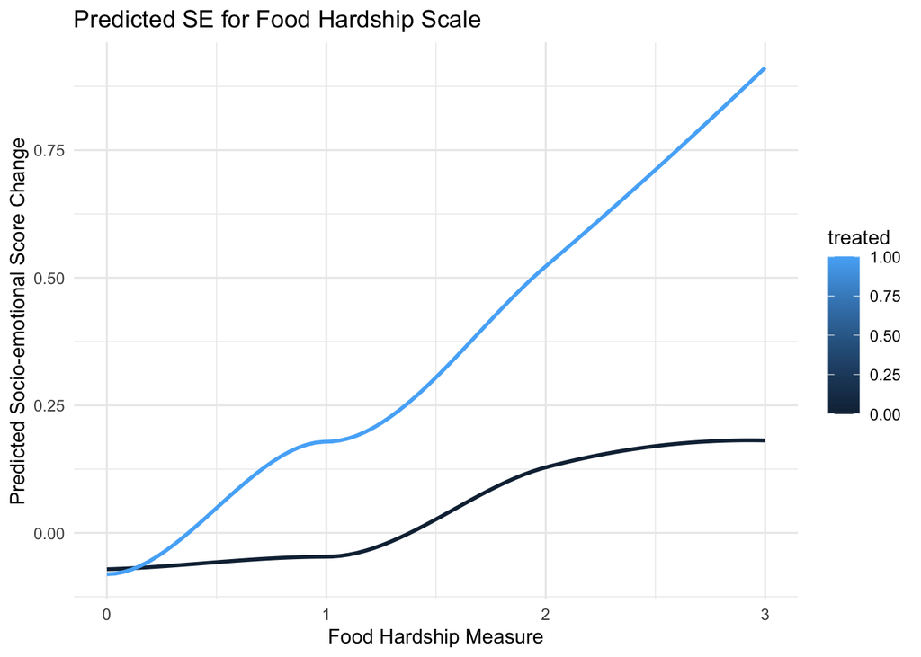

```r
predictedvars$predSE_foodhardship <- predict.glm(glmSE_food_hardship)
#predictedvars$predSE_povertyhardship <- predict.glm(glmSE_poverty_hardship) #missing values

ggplot(predictedvars, aes(x= covid_hardship_food, y= predSE_foodhardship, group= treated, color= treated)) +
  #geom_point() +             # Scatter plot of the actual data points
  #geom_line() +              # Overlay two lines based on group_var
  geom_smooth(se = F, method = "loess") +
  labs(x = "Food Hardship Measure", y = "Predicted Socio-emotional Score Change") +   # Axis labels
  ggtitle("Predicted SE for Food Hardship Scale") +  # Plot title
  theme_minimal()
```

```r
#have to construct an individual dataframe for this, due to missing data
predict.glm(glmSE_poverty_hardship)
```

[output not shown]

[output cut: 71 more lines]

[output not shown]

```r
#ggplot(predictedvars, aes(x=covid_hardship_poverty, y= predSE_povertyhardship, group= treated, color= treated)) +
#  geom_point() +             # Scatter plot of the actual data points
#  geom_line() +              # Overlay two lines based on group_var
#  geom_smooth(se = F, method = "loess") +
#  labs(x = "Poverty Hardship Measure", y = "Predicted Socio-emotional Score Change") +   # Axis labels
#  ggtitle("Scatter Plot with Two Lines by Group") +  # Plot title
#  theme_minimal()
```

## 8 Heterogeneity analysis with main model (rather than PSM)

```r
main_continuous_mat_ed <- lm(socem_total_el_z ~ socem_total_bl__z + school + treated*PED2, data = parents_comparison)
summary(main_continuous_mat_ed) #maternal education doesn't make a difference
```

```
##
## Call:
## lm(formula = socem_total_el_z ~ socem_total_bl__z + school +
##     treated * PED2, data = parents_comparison)
##
## Residuals:
##     Min      1Q  Median      3Q     Max
## -4.1775 -0.5056  0.3257  0.8411  1.8211
##
## Coefficients:
##                   Estimate Std. Error t value Pr(>|t|)
## (Intercept)       -0.17336    0.20082  -0.863   0.3884
## socem_total_bl__z  0.12968    0.05887   2.203   0.0281 *
## schoolHoly Star   -0.84709    0.21566  -3.928 9.88e-05 ***
## schoolSVN         -0.17310    0.21255  -0.814   0.4159
## treated            0.56287    0.29158   1.930   0.0542 .
## PED2               0.06359    0.06441   0.987   0.3240
## treated:PED2      -0.09169    0.09510  -0.964   0.3355
## ---
## Signif. codes:  0 '***' 0.001 '**' 0.01 '*' 0.05 '.' 0.1 ' ' 1
##
## Residual standard error: 1.226 on 463 degrees of freedom
## Multiple R-squared:  0.04514,    Adjusted R-squared:  0.03276
## F-statistic: 3.648 on 6 and 463 DF,  p-value: 0.001505
```

```r
main_prim_mat_ed <- lm(socem_total_el_z ~ treated*prim_mat_ed + socem_total_bl__z + school, data = parents_comparison)
summary(main_prim_mat_ed)
```

```
##
## Call:
## lm(formula = socem_total_el_z ~ treated * prim_mat_ed + socem_total_bl__z +
##     school, data = parents_comparison)
##
## Residuals:
##     Min      1Q  Median      3Q     Max
## -4.1633 -0.5187  0.3222  0.8291  1.8535
##
## Coefficients:
##                      Estimate Std. Error t value Pr(>|t|)
## (Intercept)          -0.03687    0.20734  -0.178   0.8589
## treated               0.51807    0.29081   1.781   0.0755 .
## prim_mat_ed1          0.05416    0.22397   0.242   0.8090
## socem_total_bl__z     0.13523    0.05810   2.328   0.0204 *
## schoolHoly Star      -0.85645    0.21456  -3.992 7.63e-05 ***
## schoolSVN            -0.20302    0.21555  -0.942   0.3467
## treated:prim_mat_ed1 -0.24757    0.30633  -0.808   0.4194
## ---
## Signif. codes:  0 '***' 0.001 '**' 0.01 '*' 0.05 '.' 0.1 ' ' 1
##
## Residual standard error: 1.226 on 463 degrees of freedom
## Multiple R-squared:  0.04466,    Adjusted R-squared:  0.03228
## F-statistic: 3.607 on 6 and 463 DF,  p-value: 0.001658
```

```r
main_sec_mat_ed <- lm(socem_total_el_z ~ treated*sec_mat_ed + socem_total_bl__z + school,  data = parents_comparison)
summary(main_sec_mat_ed)
```

```
##
## Call:
## lm(formula = socem_total_el_z ~ treated * sec_mat_ed + socem_total_bl__z +
##     school, data = parents_comparison)
##
## Residuals:
##     Min      1Q  Median      3Q     Max
## -4.1878 -0.5418  0.2969  0.8364  1.8400
##
## Coefficients:
##                     Estimate Std. Error t value Pr(>|t|)
## (Intercept)         -0.03413    0.12028  -0.284   0.7767
## treated              0.37733    0.17279   2.184   0.0295 *
## sec_mat_ed1          0.07567    0.15966   0.474   0.6358
## socem_total_bl__z    0.13011    0.05924   2.197   0.0286 *
## schoolHoly Star     -0.84208    0.21461  -3.924   0.0001 ***
## schoolSVN           -0.16839    0.21173  -0.795   0.4268
## treated:sec_mat_ed1 -0.13719    0.23013  -0.596   0.5514
## ---
## Signif. codes:  0 '***' 0.001 '**' 0.01 '*' 0.05 '.' 0.1 ' ' 1
##
## Residual standard error: 1.227 on 463 degrees of freedom
## Multiple R-squared:  0.04353,    Adjusted R-squared:  0.03114
## F-statistic: 3.512 on 6 and 463 DF,  p-value: 0.00208
```

```r
main_none_mat_ed <- lm(socem_total_el_z ~ treated*none_mat_ed + socem_total_bl__z + school, data = parents_comparison)
summary(main_none_mat_ed)
```

```
##
## Call:
## lm(formula = socem_total_el_z ~ treated * none_mat_ed + socem_total_bl__z +
##     school, data = parents_comparison)
##
## Residuals:
##     Min      1Q  Median      3Q     Max
## -4.1633 -0.5187  0.3222  0.8291  1.8535
##
## Coefficients:
##                      Estimate Std. Error t value Pr(>|t|)
## (Intercept)           0.01729    0.08487   0.204   0.8387
## treated               0.27050    0.13359   2.025   0.0435 *
## none_mat_ed1         -0.05416    0.22397  -0.242   0.8090
## socem_total_bl__z     0.13523    0.05810   2.328   0.0204 *
## schoolHoly Star      -0.85645    0.21456  -3.992 7.63e-05 ***
## schoolSVN            -0.20302    0.21555  -0.942   0.3467
## treated:none_mat_ed1  0.24757    0.30633   0.808   0.4194
## ---
## Signif. codes:  0 '***' 0.001 '**' 0.01 '*' 0.05 '.' 0.1 ' ' 1
##
## Residual standard error: 1.226 on 463 degrees of freedom
## Multiple R-squared:  0.04466,    Adjusted R-squared:  0.03228
## F-statistic: 3.607 on 6 and 463 DF,  p-value: 0.001658
```

## 9 Analysis of implementation

```r
library(readxl)
library(semPlot)
library(psych)
library(dplyr)

parents_comparison <- parents_comparison %>%
  mutate_at(vars(V01., V02., V06.),
           ~ ifelse(. == 2, 0, .))

parents_comparison$V03.read <- parents_comparison$V03.



parents_comparison <- parents_comparison %>%
  mutate(V03.read = ifelse(V03. == 1, 1, 0),
         V03.readexplain = ifelse(V03. == 2, 1, 0),
         V03.cont.needmorehelp = case_when(
           V03. == 3 ~ 0,
           V03. == 2 ~ 2,
           V03. == 1 ~ 1),
         V04.recall = ifelse(V04 == 1, 1, 0),
         V04.somerecall = ifelse(V04 == 2, 1, 0),
         V04.norecall = ifelse(V04 == 3, 1, 0),
         V04.cont.hasmorerecall = case_when(
           V04 == 3 ~ 0,
           V04 == 2 ~ 1,
           V04 == 1 ~ 2),
         V05.cont.easiertound = case_when(
           V05. == 1 ~ 2,
           V05. == 2 ~ 1,
           V05. == 3 ~ 0),
         V09.audiobest = ifelse(V09 == 1, 1, 0),
         V09.videobest = ifelse(V09 == 2, 1, 0),
         V09.bothbest = ifelse(V09== 3, 1, 0))


desclabs <- c(
  "Understood messages",
  "Received support understanding messages (reading)",
  "Received support understanding messages (reading and explaining)",
  "Needed more support (continuous)",
  "Able to recall messages",
  "Vague recall of messages",
  "No message recall",
  "Reports more recall (continuous)",
  "Found messages easier to understand (continuous)",
  "Messages were easy to apply",
  "Satisfaction (1-5)",
  "Liked audio messages most",
  "Liked video messages most",
  "Liked audio and video messages equally"
)

library(gtsummary)
library(vtable)
parents_comparison %>%
  dplyr::select(V02.,
         V03.read,
         V03.readexplain,
         V03.cont.needmorehelp,
         V04.recall,
         V04.somerecall,
         V04.norecall,
         V04.cont.hasmorerecall,
         V05.cont.easiertound,
         V06.,
         V07,
         V09.audiobest,
         V09.videobest,
         V09.bothbest) %>%  # keep only the columns of interest
  sumtable(.,
           summ=c('notNA(x)',
                  'mean(x)',
                  'sd(x)',
                  'min(x)',
                  'max(x)'),
           summ.names = list(c('N (non-missing)',
                      'Mean (%)',
                      'SD',
                      'Min',
                      'Max')),
           labels = desclabs,
           out = 'csv',
           file = 'satisfaction_desc_table.csv')
```

```
##                                                            Variable
## 1                                               Understood messages
## 2                 Received support understanding messages (reading)
## 3  Received support understanding messages (reading and explaining)
## 4                                  Needed more support (continuous)
## 5                                           Able to recall messages
## 6                                          Vague recall of messages
## 7                                                 No message recall
## 8                                  Reports more recall (continuous)
## 9                  Found messages easier to understand (continuous)
## 10                                      Messages were easy to apply
## 11                                               Satisfaction (1-5)
## 12                                        Liked audio messages most
## 13                                        Liked video messages most
## 14                           Liked audio and video messages equally
##    N (non-missing) Mean (%)   SD Min Max
## 1              218     0.33 0.47   0   1
## 2              217     0.18 0.39   0   1
## 3              217     0.82 0.39   0   1
## 4              217      1.8 0.39   1   2
## 5              225     0.33 0.47   0   1
## 6              225     0.64 0.48   0   1
## 7              225    0.031 0.17   0   1
## 8              225      1.3 0.52   0   2
## 9              213      1.3 0.47   1   2
## 10             214     0.34 0.48   0   1
## 11             216        2 0.87   1   5
## 12             224     0.49  0.5   0   1
## 13             224     0.39 0.49   0   1
## 14             224    0.085 0.28   0   1
```

```r
library(Hmisc)
cor_matrix <- parents_comparison %>%
  dplyr::select(V02.,
         V03.read,
         V03.readexplain,
         V03.cont.needmorehelp,
         V04.recall,
         V04.somerecall,
         V04.norecall,
         V04.cont.hasmorerecall,
         V05.cont.easiertound,
         V06.,
         V07,
         V09.audiobest,
         V09.videobest,
         V09.bothbest)   # keep only the columns of interest

cor_matrix <- as.matrix(cor_matrix)

cor_results <- rcorr(cor_matrix)

# Correlation coefficients
cor_matrix <- cor_results$r

# p-values matrix
p_values <- cor_results$P

# Print the correlation matrix
print(cor_matrix)
```

```
##                               V02.    V03.read V03.readexplain
## V02.                    1.00000000  0.62260080     -0.62260080
## V03.read                0.62260080  1.00000000     -1.00000000
## V03.readexplain        -0.62260080 -1.00000000      1.00000000
## V03.cont.needmorehelp  -0.62260080 -1.00000000      1.00000000
## V04.recall              0.90808353  0.62912909     -0.62912909
## V04.somerecall         -0.87977869 -0.62912909      0.62912909
## V04.norecall           -0.08295283          NA              NA
## V04.cont.hasmorerecall  0.88437692  0.62912909     -0.62912909
## V05.cont.easiertound    0.90371575  0.62636246     -0.62636246
## V06.                    0.93726921  0.62903823     -0.62903823
## V07                     0.10624410  0.44346534     -0.44346534
## V09.audiobest           0.20559183  0.21173375     -0.21173375
## V09.videobest          -0.16446494 -0.18669826      0.18669826
## V09.bothbest           -0.05975308 -0.05679193      0.05679193
##                        V03.cont.needmorehelp  V04.recall V04.somerecall
## V02.                             -0.62260080  0.90808353   -0.879778694
## V03.read                         -1.00000000  0.62912909   -0.629129091
## V03.readexplain                   1.00000000 -0.62912909    0.629129091
## V03.cont.needmorehelp             1.00000000 -0.62912909    0.629129091
## V04.recall                       -0.62912909  1.00000000   -0.933783283
## V04.somerecall                    0.62912909 -0.93378328    1.000000000
## V04.norecall                              NA -0.12670851   -0.236636572
## V04.cont.hasmorerecall           -0.62912909  0.94413996   -0.763698133
## V05.cont.easiertound             -0.62636246  0.95832709   -0.938559901
## V06.                             -0.62903823  0.98969194   -0.969582171
## V07                              -0.44346534  0.10438143   -0.103236874
## V09.audiobest                    -0.21173375  0.21135609   -0.171423762
## V09.videobest                     0.18669826 -0.18331639    0.186853554
## V09.bothbest                      0.05679193 -0.01227743   -0.004317514
##                        V04.norecall V04.cont.hasmorerecall V05.cont.easiertound
## V02.                   -0.082952832              0.8843769           0.90371575
## V03.read                         NA              0.6291291           0.62636246
## V03.readexplain                  NA             -0.6291291          -0.62636246
## V03.cont.needmorehelp            NA             -0.6291291          -0.62636246
## V04.recall             -0.126708507              0.9441400           0.95832709
## V04.somerecall         -0.236636572             -0.7636981          -0.93855990
## V04.norecall            1.000000000             -0.4465192          -0.06667211
## V04.cont.hasmorerecall -0.446519179              1.0000000           0.93961857
## V05.cont.easiertound   -0.066672114              0.9396186           1.00000000
```

[output cut: 20 more lines]

```
##                        V09.bothbest
## V02.                   -0.059753079
## V03.read               -0.056791928
## V03.readexplain         0.056791928
## V03.cont.needmorehelp   0.056791928
## V04.recall             -0.012277432
## V04.somerecall         -0.004317514
## V04.norecall            0.048734339
## V04.cont.hasmorerecall -0.026454703
## V05.cont.easiertound   -0.054059652
## V06.                   -0.030160235
## V07                     0.011286658
## V09.audiobest          -0.299049986
## V09.videobest          -0.244890395
## V09.bothbest            1.000000000
```

```r
# Print the p-values matrix
print(p_values)
```

```
##                               V02.     V03.read V03.readexplain
## V02.                            NA 0.000000e+00    0.000000e+00
## V03.read               0.000000000           NA    0.000000e+00
## V03.readexplain        0.000000000 0.000000e+00              NA
## V03.cont.needmorehelp  0.000000000 0.000000e+00    0.000000e+00
## V04.recall             0.000000000 0.000000e+00    0.000000e+00
## V04.somerecall         0.000000000 0.000000e+00    0.000000e+00
## V04.norecall           0.222523273           NA              NA
## V04.cont.hasmorerecall 0.000000000 0.000000e+00    0.000000e+00
## V05.cont.easiertound   0.000000000 0.000000e+00    0.000000e+00
## V06.                   0.000000000 0.000000e+00    0.000000e+00
## V07                    0.120384449 1.125278e-11    1.125278e-11
## V09.audiobest          0.002337306 1.708852e-03    1.708852e-03
## V09.videobest          0.015297229 5.804065e-03    5.804065e-03
## V09.bothbest           0.381075205 4.051620e-01    4.051620e-01
##                        V03.cont.needmorehelp  V04.recall V04.somerecall
## V02.                            0.000000e+00 0.000000000   0.0000000000
## V03.read                        0.000000e+00 0.000000000   0.0000000000
## V03.readexplain                 0.000000e+00 0.000000000   0.0000000000
## V03.cont.needmorehelp                     NA 0.000000000   0.0000000000
## V04.recall                      0.000000e+00          NA   0.0000000000
## V04.somerecall                  0.000000e+00 0.000000000             NA
## V04.norecall                              NA 0.057735981   0.0003425838
## V04.cont.hasmorerecall          0.000000e+00 0.000000000   0.0000000000
## V05.cont.easiertound            0.000000e+00 0.000000000   0.0000000000
## V06.                            0.000000e+00 0.000000000   0.0000000000
## V07                             1.125278e-11 0.126173576   0.1304051338
## V09.audiobest                   1.708852e-03 0.001464588   0.0101599775
## V09.videobest                   5.804065e-03 0.005929852   0.0050211341
## V09.bothbest                    4.051620e-01 0.855009394   0.9487652693
##                        V04.norecall V04.cont.hasmorerecall V05.cont.easiertound
## V02.                   2.225233e-01           0.000000e+00           0.00000000
## V03.read                         NA           0.000000e+00           0.00000000
## V03.readexplain                  NA           0.000000e+00           0.00000000
## V03.cont.needmorehelp            NA           0.000000e+00           0.00000000
## V04.recall             5.773598e-02           0.000000e+00           0.00000000
## V04.somerecall         3.425838e-04           0.000000e+00           0.00000000
## V04.norecall                     NA           2.005063e-12           0.33284484
## V04.cont.hasmorerecall 2.005063e-12                     NA           0.00000000
## V05.cont.easiertound   3.328448e-01           0.000000e+00                   NA
```

[output cut: 20 more lines]

```
##                        V09.bothbest
## V02.                   3.810752e-01
## V03.read               4.051620e-01
## V03.readexplain        4.051620e-01
## V03.cont.needmorehelp  4.051620e-01
## V04.recall             8.550094e-01
## V04.somerecall         9.487653e-01
## V04.norecall           4.679985e-01
## V04.cont.hasmorerecall 6.937350e-01
## V05.cont.easiertound   4.336039e-01
## V06.                   6.616157e-01
## V07                    8.693097e-01
## V09.audiobest          5.228369e-06
## V09.videobest          2.145876e-04
## V09.bothbest                     NA
```

```r
# Function to add stars based on significance levels
add_significance_stars <- function(cor_matrix, p_values) {
  stars <- ifelse(is.na(p_values), "",  # Replace NA with empty string
           ifelse(p_values < 0.001, "***",
           ifelse(p_values < 0.01, "**",
           ifelse(p_values < 0.05, "*", ""))))

  # Combine the correlation values with significance stars
  cor_with_stars <- matrix(paste(round(cor_matrix, 2), stars, sep=""),
                           nrow = nrow(cor_matrix), ncol = ncol(cor_matrix))
  rownames(cor_with_stars) <- rownames(cor_matrix)
  colnames(cor_with_stars) <- colnames(cor_matrix)

  return(cor_with_stars)
}

# Apply the function
cor_with_stars <- add_significance_stars(cor_matrix, p_values)

# View the correlation matrix with stars
print(cor_with_stars)
```

```
##                        V02.       V03.read   V03.readexplain
## V02.                   "1"        "0.62***"  "-0.62***"
## V03.read               "0.62***"  "1"        "-1***"
## V03.readexplain        "-0.62***" "-1***"    "1"
## V03.cont.needmorehelp  "-0.62***" "-1***"    "1***"
## V04.recall             "0.91***"  "0.63***"  "-0.63***"
## V04.somerecall         "-0.88***" "-0.63***" "0.63***"
## V04.norecall           "-0.08"    "NA"       "NA"
## V04.cont.hasmorerecall "0.88***"  "0.63***"  "-0.63***"
## V05.cont.easiertound   "0.9***"   "0.63***"  "-0.63***"
## V06.                   "0.94***"  "0.63***"  "-0.63***"
## V07                    "0.11"     "0.44***"  "-0.44***"
## V09.audiobest          "0.21**"   "0.21**"   "-0.21**"
## V09.videobest          "-0.16*"   "-0.19**"  "0.19**"
## V09.bothbest           "-0.06"    "-0.06"    "0.06"
##                        V03.cont.needmorehelp V04.recall V04.somerecall
## V02.                   "-0.62***"            "0.91***"  "-0.88***"
## V03.read               "-1***"               "0.63***"  "-0.63***"
## V03.readexplain        "1***"                "-0.63***" "0.63***"
## V03.cont.needmorehelp  "1"                   "-0.63***" "0.63***"
## V04.recall             "-0.63***"            "1"        "-0.93***"
## V04.somerecall         "0.63***"             "-0.93***" "1"
## V04.norecall           "NA"                  "-0.13"    "-0.24***"
## V04.cont.hasmorerecall "-0.63***"            "0.94***"  "-0.76***"
## V05.cont.easiertound   "-0.63***"            "0.96***"  "-0.94***"
## V06.                   "-0.63***"            "0.99***"  "-0.97***"
## V07                    "-0.44***"            "0.1"      "-0.1"
## V09.audiobest          "-0.21**"             "0.21**"   "-0.17*"
## V09.videobest          "0.19**"              "-0.18**"  "0.19**"
## V09.bothbest           "0.06"                "-0.01"    "0"
##                        V04.norecall V04.cont.hasmorerecall V05.cont.easiertound
## V02.                   "-0.08"      "0.88***"              "0.9***"
## V03.read               "NA"         "0.63***"              "0.63***"
## V03.readexplain        "NA"         "-0.63***"             "-0.63***"
## V03.cont.needmorehelp  "NA"         "-0.63***"             "-0.63***"
## V04.recall             "-0.13"      "0.94***"              "0.96***"
## V04.somerecall         "-0.24***"   "-0.76***"             "-0.94***"
## V04.norecall           "1"          "-0.45***"             "-0.07"
## V04.cont.hasmorerecall "-0.45***"   "1"                    "0.94***"
## V05.cont.easiertound   "-0.07"      "0.94***"              "1"
```

[output cut: 20 more lines]

```
##                        V09.bothbest
## V02.                   "-0.06"
## V03.read               "-0.06"
## V03.readexplain        "0.06"
## V03.cont.needmorehelp  "0.06"
## V04.recall             "-0.01"
## V04.somerecall         "0"
## V04.norecall           "0.05"
## V04.cont.hasmorerecall "-0.03"
## V05.cont.easiertound   "-0.05"
## V06.                   "-0.03"
## V07                    "0.01"
## V09.audiobest          "-0.3***"
## V09.videobest          "-0.24***"
## V09.bothbest           "1"
```

```r
rownames(cor_with_stars) <- desclabs
colnames(cor_with_stars) <- desclabs
# Write the correlation matrix with stars to a CSV file
write.csv(cor_with_stars, "C:\\Users\\berta\\Dropbox\\Mumbai COVID Project\\correlation_matrix_with_stars.csv", row.names = TRUE)


#with the outcomes
desclabs2 <- c(
  "Socioemotional outcomes at EL",
  "Academic outcomes at EL",
  "Cognitive outcomes at EL",
  "Behavioral outcomes at EL",
  "Educational engagement at EL",
  "Understood messages",
  "Received support understanding messages (reading)",
  "Received support understanding messages (reading and explaining)",
  "Needed more support (continuous)",
  "Able to recall messages",
  "Vague recall of messages",
  "No message recall",
  "Reports more recall (continuous)",
  "Found messages easier to understand (continuous)",
  "Messages were easy to apply",
  "Satisfaction (1-5)",
  "Liked audio messages most",
  "Liked video messages most",
  "Liked audio and video messages equally"
)

cor_matrix2 <- parents_comparison %>%
  dplyr::select(socem_total_el_z,
                acad_total_el_z,
                cog_outcomes_endline_z,
                behavior_endline_z,
                educ_engagement_endline_z,
                V02.,
                V03.read,
                V03.readexplain,
                V03.cont.needmorehelp,
                V04.recall,
                V04.somerecall,
                V04.norecall,
                V04.cont.hasmorerecall,
                V05.cont.easiertound,
                V06.,
                V07,
                V09.audiobest,
                V09.videobest,
                V09.bothbest)   # keep only the columns of interest

cor_matrix2 <- as.matrix(cor_matrix2)

cor_results2 <- rcorr(cor_matrix2)

# Correlation coefficients
cor_matrix2 <- cor_results2$r

# p-values matrix
p_values2 <- cor_results2$P

# Print the correlation matrix
print(cor_matrix2)
```

```
##                           socem_total_el_z acad_total_el_z
## socem_total_el_z               1.000000000     0.316543492
## acad_total_el_z                0.316543492     1.000000000
## cog_outcomes_endline_z        -0.476804799    -0.884415749
## behavior_endline_z             0.150332800     0.058920729
## educ_engagement_endline_z      0.218107036     0.431967572
## V02.                          -0.047434049    -0.071593464
## V03.read                       0.015489237    -0.074592286
## V03.readexplain               -0.015489237     0.074592286
## V03.cont.needmorehelp         -0.015489237     0.074592286
## V04.recall                     0.030509540    -0.011523108
## V04.somerecall                -0.068901498    -0.005351826
## V04.norecall                   0.108157948     0.046122751
## V04.cont.hasmorerecall        -0.008411536    -0.025717370
## V05.cont.easiertound           0.045682318    -0.031097167
## V06.                           0.039830876    -0.003914804
## V07                            0.059219009     0.037965050
## V09.audiobest                 -0.065885314    -0.064096800
## V09.videobest                  0.117003841     0.073926438
## V09.bothbest                  -0.136499699    -0.043812128
##                           cog_outcomes_endline_z behavior_endline_z
## socem_total_el_z                     -0.47680480        0.150332800
## acad_total_el_z                      -0.88441575        0.058920729
## cog_outcomes_endline_z                1.00000000       -0.053813189
## behavior_endline_z                   -0.05381319        1.000000000
## educ_engagement_endline_z            -0.45147102        0.115309575
## V02.                                  0.08154368        0.001027723
## V03.read                              0.03465843        0.114613956
## V03.readexplain                      -0.03465843       -0.114613956
## V03.cont.needmorehelp                -0.03465843       -0.114613956
## V04.recall                            0.03647923        0.043942468
## V04.somerecall                       -0.01231085       -0.039766820
## V04.norecall                         -0.06492174       -0.009077055
## V04.cont.hasmorerecall                0.05447435        0.042653665
## V05.cont.easiertound                  0.05954763        0.007843920
## V06.                                  0.03835582        0.032219327
## V07                                  -0.04268089        0.198259066
## V09.audiobest                         0.03448987        0.087306104
## V09.videobest                        -0.04093882       -0.087692041
## V09.bothbest                          0.03972606       -0.063401706
```

[output cut: 85 more lines]

```
## educ_engagement_endline_z   -0.02675529    0.01933214  0.034357963
## V02.                         0.20559183   -0.16446494 -0.059753079
## V03.read                     0.21173375   -0.18669826 -0.056791928
## V03.readexplain             -0.21173375    0.18669826  0.056791928
## V03.cont.needmorehelp       -0.21173375    0.18669826  0.056791928
## V04.recall                   0.21135609   -0.18331639 -0.012277432
## V04.somerecall              -0.17142376    0.18685355 -0.004317514
## V04.norecall                -0.10765491   -0.02021973  0.048734339
## V04.cont.hasmorerecall       0.22679124   -0.16119169 -0.026454703
## V05.cont.easiertound         0.17542665   -0.14978685 -0.054059652
## V06.                         0.19757660   -0.18445045 -0.030160235
## V07                          0.17707685   -0.20869101  0.011286658
## V09.audiobest                1.00000000   -0.79016138 -0.299049986
## V09.videobest               -0.79016138    1.00000000 -0.244890395
## V09.bothbest                -0.29904999   -0.24489040  1.000000000
```

```r
# Print the p-values matrix
print(p_values2)
```

```
##                           socem_total_el_z acad_total_el_z
## socem_total_el_z                        NA    2.130074e-12
## acad_total_el_z               2.130074e-12              NA
## cog_outcomes_endline_z        0.000000e+00    0.000000e+00
## behavior_endline_z            1.079071e-03    2.022818e-01
## educ_engagement_endline_z     1.811016e-06    0.000000e+00
## V02.                          4.859773e-01    2.926442e-01
## V03.read                      8.205276e-01    2.739588e-01
## V03.readexplain               8.205276e-01    2.739588e-01
## V03.cont.needmorehelp         8.205276e-01    2.739588e-01
## V04.recall                    6.489653e-01    8.635243e-01
## V04.somerecall                3.034847e-01    9.363718e-01
## V04.norecall                  1.056447e-01    4.912297e-01
## V04.cont.hasmorerecall        9.001495e-01    7.012190e-01
## V05.cont.easiertound          5.072444e-01    6.517829e-01
## V06.                          5.622567e-01    9.545982e-01
## V07                           3.864637e-01    5.789408e-01
## V09.audiobest                 3.262815e-01    3.396140e-01
## V09.videobest                 8.057448e-02    2.705714e-01
## V09.bothbest                  4.124348e-02    5.141660e-01
##                           cog_outcomes_endline_z behavior_endline_z
## socem_total_el_z                       0.0000000        0.001079071
## acad_total_el_z                        0.0000000        0.202281804
## cog_outcomes_endline_z                        NA        0.244270294
## behavior_endline_z                     0.2442703                 NA
## educ_engagement_endline_z              0.0000000        0.012365286
## V02.                                   0.2305069        0.987962840
## V03.read                               0.6116256        0.092148444
## V03.readexplain                        0.6116256        0.092148444
## V03.cont.needmorehelp                  0.6116256        0.092148444
## V04.recall                             0.5862199        0.511964007
## V04.somerecall                         0.8542950        0.552903656
## V04.norecall                           0.3323331        0.892295420
## V04.cont.hasmorerecall                 0.4161217        0.524430279
## V05.cont.easiertound                   0.3871910        0.909391301
## V06.                                   0.5768332        0.639291718
## V07                                    0.5326781        0.003433567
## V09.audiobest                          0.6076282        0.192966010
## V09.videobest                          0.5421640        0.190998178
## V09.bothbest                           0.5542040        0.344887832
```

[output cut: 85 more lines]

```
## educ_engagement_endline_z  6.904330e-01  0.7735418295 6.090031e-01
## V02.                       2.337306e-03  0.0152972294 3.810752e-01
## V03.read                   1.708852e-03  0.0058040655 4.051620e-01
## V03.readexplain            1.708852e-03  0.0058040655 4.051620e-01
## V03.cont.needmorehelp      1.708852e-03  0.0058040655 4.051620e-01
## V04.recall                 1.464588e-03  0.0059298523 8.550094e-01
## V04.somerecall             1.015998e-02  0.0050211341 9.487653e-01
## V04.norecall               1.080785e-01  0.7634458535 4.679985e-01
## V04.cont.hasmorerecall     6.262536e-04  0.0157433633 6.937350e-01
## V05.cont.easiertound       1.049662e-02  0.0292314733 4.336039e-01
## V06.                       3.789633e-03  0.0069480247 6.616157e-01
## V07                        9.270497e-03  0.0020971768 8.693097e-01
## V09.audiobest                        NA  0.0000000000 5.228369e-06
## V09.videobest              0.000000e+00            NA 2.145876e-04
## V09.bothbest               5.228369e-06  0.0002145876           NA
```

```r
# Function to add stars based on significance levels
add_significance_stars <- function(cor_matrix2, p_values2) {
  stars <- ifelse(is.na(p_values2), "",  # Replace NA with empty string
           ifelse(p_values2 < 0.001, "***",
           ifelse(p_values2 < 0.01, "**",
           ifelse(p_values2 < 0.05, "*", ""))))

  # Combine the correlation values with significance stars
  cor_with_stars <- matrix(paste(round(cor_matrix2, 2), stars, sep=""),
                           nrow = nrow(cor_matrix2), ncol = ncol(cor_matrix2))
  rownames(cor_with_stars) <- rownames(cor_matrix2)
  colnames(cor_with_stars) <- colnames(cor_matrix2)

  return(cor_with_stars)
}

# Apply the function
cor_with_stars <- add_significance_stars(cor_matrix2, p_values2)

# View the correlation matrix with stars
print(cor_with_stars)
```

```
##                           socem_total_el_z acad_total_el_z
## socem_total_el_z          "1"              "0.32***"
## acad_total_el_z           "0.32***"        "1"
## cog_outcomes_endline_z    "-0.48***"       "-0.88***"
## behavior_endline_z        "0.15**"         "0.06"
## educ_engagement_endline_z "0.22***"        "0.43***"
## V02.                      "-0.05"          "-0.07"
## V03.read                  "0.02"           "-0.07"
## V03.readexplain           "-0.02"          "0.07"
## V03.cont.needmorehelp     "-0.02"          "0.07"
## V04.recall                "0.03"           "-0.01"
## V04.somerecall            "-0.07"          "-0.01"
## V04.norecall              "0.11"           "0.05"
## V04.cont.hasmorerecall    "-0.01"          "-0.03"
## V05.cont.easiertound      "0.05"           "-0.03"
## V06.                      "0.04"           "0"
## V07                       "0.06"           "0.04"
## V09.audiobest             "-0.07"          "-0.06"
## V09.videobest             "0.12"           "0.07"
## V09.bothbest              "-0.14*"         "-0.04"
##                           cog_outcomes_endline_z behavior_endline_z
## socem_total_el_z          "-0.48***"             "0.15**"
## acad_total_el_z           "-0.88***"             "0.06"
## cog_outcomes_endline_z    "1"                    "-0.05"
## behavior_endline_z        "-0.05"                "1"
## educ_engagement_endline_z "-0.45***"             "0.12*"
## V02.                      "0.08"                 "0"
## V03.read                  "0.03"                 "0.11"
## V03.readexplain           "-0.03"                "-0.11"
## V03.cont.needmorehelp     "-0.03"                "-0.11"
## V04.recall                "0.04"                 "0.04"
## V04.somerecall            "-0.01"                "-0.04"
## V04.norecall              "-0.06"                "-0.01"
## V04.cont.hasmorerecall    "0.05"                 "0.04"
## V05.cont.easiertound      "0.06"                 "0.01"
## V06.                      "0.04"                 "0.03"
## V07                       "-0.04"                "0.2**"
## V09.audiobest             "0.03"                 "0.09"
## V09.videobest             "-0.04"                "-0.09"
## V09.bothbest              "0.04"                 "-0.06"
```

[output cut: 85 more lines]

```
## educ_engagement_endline_z "-0.03"       "0.02"        "0.03"
## V02.                      "0.21**"      "-0.16*"      "-0.06"
## V03.read                  "0.21**"      "-0.19**"     "-0.06"
## V03.readexplain           "-0.21**"     "0.19**"      "0.06"
## V03.cont.needmorehelp     "-0.21**"     "0.19**"      "0.06"
## V04.recall                "0.21**"      "-0.18**"     "-0.01"
## V04.somerecall            "-0.17*"      "0.19**"      "0"
## V04.norecall              "-0.11"       "-0.02"       "0.05"
## V04.cont.hasmorerecall    "0.23***"     "-0.16*"      "-0.03"
## V05.cont.easiertound      "0.18*"       "-0.15*"      "-0.05"
## V06.                      "0.2**"       "-0.18**"     "-0.03"
## V07                       "0.18**"      "-0.21**"     "0.01"
## V09.audiobest             "1"           "-0.79***"    "-0.3***"
## V09.videobest             "-0.79***"    "1"           "-0.24***"
## V09.bothbest              "-0.3***"     "-0.24***"    "1"
```

```r
rownames(cor_with_stars) <- desclabs2
colnames(cor_with_stars) <- desclabs2
# Write the correlation matrix with stars to a CSV file
#write.csv(cor_with_stars, row.names = TRUE)
```